Luis Antonio Ortega Andrés  
Antonio Coín Castro

```python
from qiskit import QuantumCircuit, QuantumRegister, ClassicalRegister, Aer, IBMQ, execute
from qiskit.visualization import plot_histogram, plot_bloch_multivector
from qiskit_textbook.tools import array_to_latex

%matplotlib inline

# Load IBM account
provider = IBMQ.load_account()
```

# Algoritmo de phase-kickback

Estudiamos el algoritmo (o fenómeno) de *phase kickback*. Se trata de un fenómeno por el cual, tras la aplicación de una puerta controlada en unas ciertas condiciones, la información de la fase que presenta el *target* se transmite al qubit de *control*. Es decir, incluso aunque la puerta controlada en teoría no modifica el qubit de control, existe una manera de que sí lo modifique (y deje intacto el qubit *target*).

## Phase kickback con la puerta CNOT

Veamos un ejemplo de esta situación con la puerta CNOT. Consideremos primero el siguiente circuito:

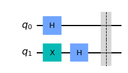

```python
qc = QuantumCircuit(2)
qc.h(0)
qc.x(1)
qc.h(1)
qc.barrier()
qc.draw('mpl')
```

Podemos ver el estado en el que se encuentra el circuito en la barrera.

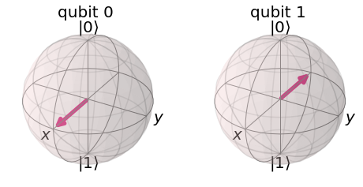

```python
backend = Aer.get_backend('statevector_simulator')
psi = execute(qc, backend).result().get_statevector()
plot_bloch_multivector(psi)
```

Introduzcamos ahora una puerta CNOT poniendo $q_0$ como qubit de control. En teoría, esta puerta solo debería modificar eventualmente el estado de $q_1$.

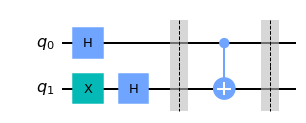

```python
qc.cx(0, 1)
qc.barrier()
qc.draw('mpl')
```

Pero si medimos ahora el estado del circuito tras la segunda barrera...

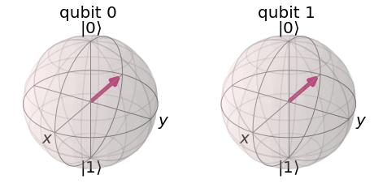

```python
psi = execute(qc, backend).result().get_statevector()
plot_bloch_multivector(psi)
```

¡Sorpresa! El estado de $q_1$ ha quedado igual, mientras que **el estado de $q_0$ es el que ha cambiado**. Lo que ocurre es que, en cierto modo, el qubit $q_1$ "le ha pasado" (*kick-back*) su cambio a $q_0$.

## Phase kickback con una puerta genérica

Consideremos ahora el caso general de una puerta cuántica de un qubit $U$ y su correspondiente puerta controlada. Supongamos además que conocemos un autovector de la puerta $U$, digamos $|\psi\rangle$, con autovalor asociado $e^{2\pi i\theta}$. Es decir:

$$U|\psi\rangle=e^{2\pi i\theta}|\psi\rangle.$$

*Nota: como la puerta $U$ debe ser unitaria, todos sus autovalores deben tener módulo $1$, por lo que un autovalor genérico puede efectivamente expresarse como $e^{2\pi i\theta}$ para cierto $\theta \in \mathbb R$.*

Consideremos ahora el siguiente circuito cuántico, y analicemos paso a paso su estado (introducimos la notación $|\psi\rangle \otimes |\varphi\rangle \equiv |\psi\rangle|\varphi\rangle$):

[figure not shown]

- En el punto $A$, el estado del sistema es simplemente $|0\rangle|\psi\rangle$.
- En el punto $B$, tras la aplicación de una puerta de Hadamard a $q_0$, el estado conjunto es $$H|0\rangle|\psi\rangle=\frac{|0\rangle + |1\rangle}{\sqrt{2}}|\psi\rangle=\frac{|0\rangle|\psi\rangle + |1\rangle|\psi\rangle}{\sqrt{2}}.$$
- Finalmente, aplicamos una puerta Controlled-$U$ en el punto $C$. Recordamos que esta puerta solo actúa sobre $q_1$ (aplicando $U$) cuando el estado de $q_0$ es $|1\rangle$. Por tanto, utilizando también que $|\psi\rangle$ es un autovector de $U$, llegamos al estado conjunto: $$\frac{|0\rangle|\psi\rangle + |1\rangle U|\psi\rangle}{\sqrt{2}} = \frac{|0\rangle|\psi\rangle + |1\rangle e^{2\pi i\theta}|\psi\rangle}{\sqrt{2}}=\frac{|0\rangle|\psi\rangle + e^{2\pi i\theta}|1\rangle |\psi\rangle}{\sqrt{2}}=\frac{|0\rangle + e^{2\pi i\theta}|1\rangle}{\sqrt{2}}|\psi\rangle.$$

*Nota: hemos usado en repetidas ocasiones la bilinealidad del producto tensor para simplificar los cálculos.*

Es decir, vemos como en el estado final del circuito el qubit $q_1$, $|\psi\rangle$, no se ha modificado, mientras que el qubit $q_0$ ha recibido justamente la fase $e^{2\pi i\theta}$ del autovalor de $U$. Este fenómeno se utiliza con frecuencia para la implementación de algoritmos cuánticos.

En el ejemplo anterior con la puerta CNOT estábamos usando que $|0\rangle - |1\rangle=(1, -1)^T$ es un autovector de la puerta NOT, con autovalor asociado $-1$.